# HELPmiss (Data Verbs) Activity

Yaowen Tan

2021/2/22

Assigned Exercises DC Chapter 7 Exercises: 7.1, 7.3, 7.5, 7.6, 7.7, 7.8

```r
# clean up workspace environment
rm(list = ls())

#install.packages("devtools")
#library(devtools)
#install_github("mdbeckman/dcData")


# all packages used for the assignment
library(tidyverse)
library(esquisse)
library(mosaicData)
library(dcData)
library(ggplot2)
install.packages("remotes")
remotes::install_github("DataComputing/DataComputing")
library(DataComputing)
```

# Chapter 7 Exercises

## Problem 7.1

1.Determine the 3rd largest: Reduction function

2.Determine the 3rd and 4th largest values: Reduction function

3.Determine the number of cases: Reduction function

4.Determine whether a year is a leap year: Transformation function

5.Determine whether a date is a legal holiday: Neither

6.Determine the range of a set, that is, the max minus the min: Transformation function

7.Determine which day of the week (e.g., Sun, Mon, …) a given date is: Neither

8.Find the time interval in days spanned by a set of dates: Transformation function

## Problem 7.3

1 How many cases are there?

```r
data("Minneapolis2013", package = "dcData")

Minneapolis2013 %>%
  summarise(count = n())
```

| count |
| --- |
| 80101 |

There are 80101 cases

2.Who were the top 5 candidates in the Second vote selections.

```r
data("Minneapolis2013", package = "dcData")

Minneapolis2013 %>%
  group_by(Second) %>%
  tally(sort=TRUE) %>%
  head(6)
```

| Second | n |
| --- | --- |
| BETSY HODGES | 14399 |
| DON SAMUELS | 14170 |
| MARK ANDREW | 12757 |
| undervote | 10598 |
| JACKIE CHERRYHOMES | 6470 |
| BOB FINE | 3751 |

The top 5 candidates are BESTY HODGES, DON SAMUELS, MARK ANDREW, JACKIE CHERRYHOMES, and BOB FINE.

3. How many ballots are marked “undervote” in

First choice selections:834

```r
Minneapolis2013 %>%
  group_by(First) %>%
  filter(First=="undervote") %>%
  summarise(count = n())
```

| First | count |
| --- | --- |
| undervote | 834 |

Second choice selections: 10598

```r
Minneapolis2013 %>%
  group_by(Second) %>%
  filter(Second =="undervote") %>%
  summarise(count = n())
```

| Second | count |
| --- | --- |
| undervote | 10598 |

Third choice selections: 19210

```r
Minneapolis2013 %>%
  group_by(Third) %>%
  filter(Third =="undervote") %>%
  summarise(count = n())
```

| Third | count |
| --- | --- |
| undervote | 19210 |

4.What are the top 3 combinations of First and Second vote selections? (That is, of all the possible ways a voter might have marked his or her first and second choices, which received the highest number of votes?)

```r
Minneapolis2013 %>%
  group_by(First, Second) %>%
  summarise(count=n()) %>%
  arrange(desc(count))%>%
  head(3)
```

| First | Second | count |
| --- | --- | --- |
| BETSY HODGES | MARK ANDREW | 8787 |
| BETSY HODGES | DON SAMUELS | 8743 |
| MARK ANDREW | BETSY HODGES | 6970 |

```r
Minneapolis2013 %>%
  group_by(First, Second, Third) %>%
  summarise(count=n()) %>%
  arrange(desc(count))%>%
  head(3)
```

| First | Second | Third | count |
| --- | --- | --- | --- |
| MARK ANDREW | undervote | undervote | 3864 |
| BETSY HODGES | MARK ANDREW | DON SAMUELS | 3309 |
| BETSY HODGES | DON SAMUELS | MARK ANDREW | 3031 |

## Problem 7.5

a

```r
VoterData_A <-
  Minneapolis2013 %>%
  group_by(First, Second)
VoterData_A
```

| Precinct | First | Second | Third | Ward |
| --- | --- | --- | --- | --- |
| P-10 | BETSY HODGES | undervote | undervote | W-7 |
| P-06 | BOB FINE | MARK ANDREW | undervote | W-10 |
| P-09 | KURTIS W. HANNA | BOB FINE | MIKE GOULD | W-10 |
| P-05 | BETSY HODGES | DON SAMUELS | undervote | W-13 |
| P-01 | DON SAMUELS | undervote | undervote | W-5 |
| P-04 | undervote | undervote | undervote | W-6 |
| P-05 | BETSY HODGES | MARK ANDREW | DON SAMUELS | W-1 |
| P-01 | BETSY HODGES | MARK ANDREW | undervote | W-12 |
| P-06 | CAM WINTON | undervote | undervote | W-4 |
| P-02D | NEAL BAXTER | BETSY HODGES | DON SAMUELS | W-7 |

[output cut: 990 more lines]

VoterData_A is a new data name and the data “Minneapolis2013” is assigned to it. This query group the data in Minneapolis2013 by First and Second, then assign them to VoterData_A. Each case represents a precinct of the voter with the voter’s first choice and second choice.

b

```r
VoterData_B <-
  Minneapolis2013 %>%
  summarise( total = n() )
VoterData_B
```

| total |
| --- |
| 80101 |

We can see the the number of total case of the Minneapolis2013 dataset is 80101. The case in the the VoterData_B represents the total number of cases in the original data.

c

```r
VoterData_C <-
  Minneapolis2013 %>%
  group_by(First, Second) %>%
  summarise( total = n() )
VoterData_C
```

| First | Second | total |
| --- | --- | --- |
| ABDUL M RAHAMAN "THE ROCK" | ABDUL M RAHAMAN "THE ROCK" | 69 |
| ABDUL M RAHAMAN "THE ROCK" | ALICIA K. BENNETT | 3 |
| ABDUL M RAHAMAN "THE ROCK" | BETSY HODGES | 29 |
| ABDUL M RAHAMAN "THE ROCK" | BILL KAHN | 18 |
| ABDUL M RAHAMAN "THE ROCK" | BOB "AGAIN" CARNEY JR | 3 |
| ABDUL M RAHAMAN "THE ROCK" | BOB FINE | 3 |
| ABDUL M RAHAMAN "THE ROCK" | CAM WINTON | 2 |
| ABDUL M RAHAMAN "THE ROCK" | CAPTAIN JACK SPARROW | 8 |
| ABDUL M RAHAMAN "THE ROCK" | CYD GORMAN | 1 |
| ABDUL M RAHAMAN "THE ROCK" | DAN COHEN | 2 |

[output cut: 990 more lines]

```r
NA
```

We can see the data of the first choice and the second choice

d

```r
VoterData_D <-
  Minneapolis2013 %>%
  summarise( total = n() ) %>%
  group_by(First, Second)
```

```
错误: Must group by variables found in `.data`.
* Column `First` is not found.
* Column `Second` is not found.
Run `rlang::last_error()` to see where the error occurred.
```

We can see the data have been choosen so that the original variables are not exist in the new data. So we cannot find any columns or variables call “First” and “Second” in VoterData_D.

## Problem 7.6

```r
#install.packages("remotes")
#remotes::install_github("dtkaplan/DCF")
data("ZipGeography", package = "dcData")
DATA7 <-
  ZipGeography %>%
  group_by(State) %>%
  summarise(Land = sum(LandArea,na.rm = TRUE), Pop = sum(Population,na.rm = TRUE))
DATA7
```

| State | Land | Pop |
| --- | --- | --- |
|  | 1485.3 | 741752 |
| Massachusetts | 20195.9 | 6349048 |
| New Hampshire | 21494.3 | 1235735 |
| New York | 119306.3 | 18974619 |
| Rhode Island | 2706.3 | 1048319 |
| Maine | 54695.7 | 1273094 |
| Vermont | 23874.6 | 608822 |
| Connecticut | 12548.2 | 3405565 |
| New Jersey | 18385.2 | 8413990 |
| Pennsylvania | 112861.8 | 12280587 |

[output cut: 43 more lines]

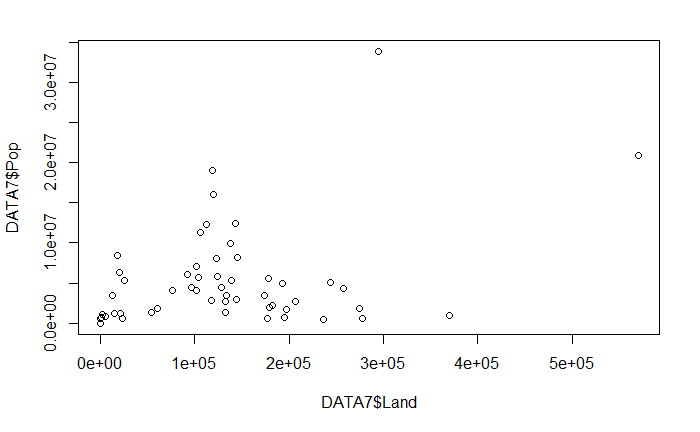

```r
plot(DATA7$Land, DATA7$Pop)
```

From the graph, we can see that there is a weak positive relationship between population and LandArea.

2

```r
#install.packages("usmap")
#library(tidyverse)
#install.package("devtools")
#devtools::install_github("pdil/usmap")
library(usmap)

ZipGeography %>%
  usmap(key="State",fill = "Population")
```

[output not shown]

## Problem 7.7

a.sex: sex, count, meanAge.

b.diagnosis: diagnosis, count, meanAge.

c.sex, diagnosis: sex, diagnosis, count, meanAge.

d.age, diagnosis: age,diagnosis, count, meanAge.

e.age: age, count, meanAge

## Problem 7.8

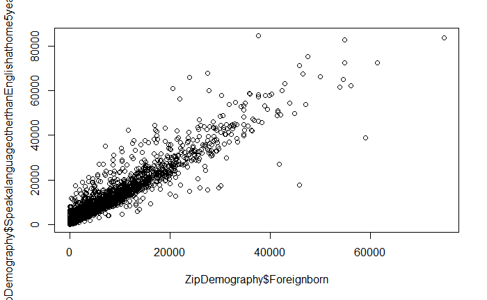

```r
data("ZipDemography", package = "dcData")
plot(ZipDemography$Foreignborn, ZipDemography$SpeakalanguageotherthanEnglishathome5yearsandover)
```

2. We know that there are 50 states in U.S., which means that there a lot of people get B.A or higher degree. We can set the total population as denominator, and people who get B.A. or higher degree as partition so that the precent shows the level of education